```python
from IPython.display import HTML
HTML('''<script>
  function code_toggle() {
    if (code_shown){
      $('div.input').hide('500');
      $('#toggleButton').val('Show Code')
    } else {
      $('div.input').show('500');
      $('#toggleButton').val('Hide Code')
    }
    code_shown = !code_shown
  }

  $( document ).ready(function(){
    code_shown=false;
    $('div.input').hide()
  });
</script>
<form action="javascript:code_toggle()"><input type="submit" id="toggleButton" value="Show Code"></form>''')
```

# The Robots Are Coming For Your Teaching Job: Educational Ramifications in the Machine Learning Age

### Matthew Moran

### matthew.j.moran@gmail.com

### MMC Friday Talk -- January 18, 2019

[figure not shown]

## Data Scientist Responsibilities:

- Apply a variety of machine learning techniques, from linear regression to the latest neural network modeling techniques to improve the efficacy of our educational materials and pedagogy.
- Design data collection approaches that capture relevant user behavior to enhance both content and overall learning experience.
- Source: Pearson Job Listing

## We are looking for a Senior Data Scientist with:

- Ph.D. in a quantitative field or relevant experience.
- 5 years experience with education or AI systems, specializing in one or more of the following: computer adaptive testing, deep learning, and/or reinforcement learning. Have the ability to adapt those methods in new situations.
- Strong coding skills in Python including experience shepherding exploratory research code into prototypes. Experience with deep learning frameworks (such as TensorFlow). Experience with other languages, such as R, and ability to move between languages and frameworks a plus
- Source: Pearson Job Listing

## Software Developer

- Working in a small team, you will create and deliver commercial software services that **automatically evaluate student writing**. Primary responsibility is to create, test, and maintain machine-learning based services used in a variety of assessment and learning situations from K-20 and beyond.
- Source: Pearson Job Listing

## Is the robot takeover imminent? Will it ever be a good thing? Is it already good?

- Good or bad, there is money and research being poured into these efforts.
- Humanoid robots
  - Yes, the videos are laughable, but is there potential?
    - Language
    - Children with Autism
    - Reading Emotions

## Is the robot takeover imminent? Will it ever be a good thing? Is it already good?

- Good or bad, there is money and research being poured into these efforts.
- Assistive learning software systems
  - *Differentiated Instruction*

## Is the robot takeover imminent? Will it ever be a good thing? Is it already good?

- Good or bad, there is money and research being poured into these efforts.
- Robo-grading
  - Sounds great
  - Hard for math?

# How are these systems built?

- Understand the data transformations
- Understand the compromises (trading quality for convenience?)

# What is Machine Learning?

# What is Machine Learning?

## Consider the familiar example -- RM is average number of rooms, MEDV is median value in $1000s

## We will try to predict the value of a home from the number of rooms.

```python
only_rooms_df.head(10)
```

|  | RM | MEDV |
| --- | --- | --- |
| 0 | 6.575 | 24.0 |
| 1 | 6.421 | 21.6 |
| 2 | 7.185 | 34.7 |
| 3 | 6.998 | 33.4 |
| 4 | 7.147 | 36.2 |
| 5 | 6.430 | 28.7 |
| 6 | 6.012 | 22.9 |
| 7 | 6.172 | 27.1 |
| 8 | 5.631 | 16.5 |
| 9 | 6.004 | 18.9 |

# Does there seem to be any correlation between number of rooms and price?

```python
ax = sns.scatterplot(x="RM", y="MEDV", data=only_rooms_df)
```

[output not shown]

```python
ax = sns.scatterplot(x="RM", y="MEDV", data=only_rooms_df)
```

[output not shown]

## Let's see if we can *fit a line* to this data.

```python
ax = sns.scatterplot(x="RM", y="MEDV", data=only_rooms_df)
```

[output not shown]

# Big Idea

## We have a bunch of data points that sort of make a line.

## We want to find values for $a$ and $b$ in $y = ax + b$ that *fit* the data points.

## We define a criterion for how well a line fits the data.

## We look for a line that optimizes our criterion.

- Using an optimization algorithm like gradient descent (note: better ways to optimize for linear regression)

## Let's define our criterion for the $a$ and $b$ that make $y = ax + b$ fit our data the best to be the squared error criterion.

### So we are going to take the difference between the predicted value and the actual value, square it, and call that our error. We want $a$ and $b$ such that the sum of these *errors* is as small as possible.

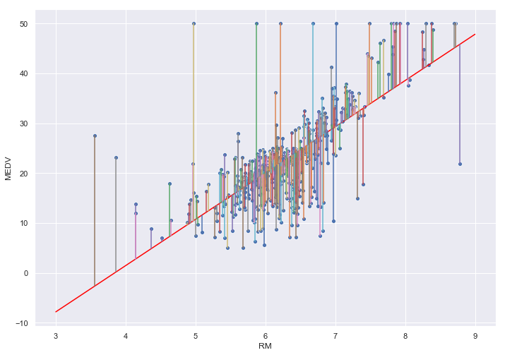

```python
dataset = boston_df
ax = sns.scatterplot(x="RM", y="MEDV", data=dataset)
x = np.linspace(3, 9, 1000)
ax.plot(x, 9.274 * x - 35.64, color='red')

for row in dataset.itertuples():
    ax.plot([row.RM, row.RM], [row.MEDV, 9.274 * row.RM - 35.64])
```

## In this case $a \approx 9.3$ and $b \approx -35.6$. So we have

$$ \text{MEDV} = 9.3 * \text{RM} - 35.6 $$

```python
X_test.head()
```

|  | RM | MEDV | prediction |
| --- | --- | --- | --- |
| 81 | 6.619 | 23.9 | 25.742407 |
| 453 | 7.393 | 17.8 | 32.920237 |
| 311 | 6.122 | 22.1 | 21.133387 |
| 291 | 7.148 | 37.3 | 30.648185 |
| 360 | 6.398 | 25.0 | 23.692923 |

```python
X_test.head()
```

|  | RM | MEDV | prediction | diff_squared |
| --- | --- | --- | --- | --- |
| 81 | 6.619 | 23.9 | 25.742407 | 3.394464 |
| 453 | 7.393 | 17.8 | 32.920237 | 228.621576 |
| 311 | 6.122 | 22.1 | 21.133387 | 0.934341 |
| 291 | 7.148 | 37.3 | 30.648185 | 44.246642 |
| 360 | 6.398 | 25.0 | 23.692923 | 1.708450 |

## So we sum this *dif_squared* column and divide by the number of entries to get our *Mean Squared Error* -- in this case it is about 42.77 (this is on our testing data).

```python
rooms_lstat_df = pd.DataFrame(np.c_[boston_df['RM'], boston_df['LSTAT'], boston_df['MEDV']], columns=['RM', 'LSTAT', 'MEDV'])
train, test = train_test_split(rooms_lstat_df, test_size = 0.25, random_state=666)
lin_model = LinearRegression()
lin_model.fit(np.c_[train['RM'], train['LSTAT']], train['MEDV'].to_frame())
```

```
LinearRegression(copy_X=True, fit_intercept=True, n_jobs=None,
         normalize=False)
```

## Now consider the same problem, except we know more about the housing market.

## We add a column of data *LSTAT* that tells us the percentage of the neighborhood that is *low income*.

```python
rooms_lstat_df.head()
```

|  | RM | LSTAT | MEDV |
| --- | --- | --- | --- |
| 0 | 6.575 | 4.98 | 24.0 |
| 1 | 6.421 | 9.14 | 21.6 |
| 2 | 7.185 | 4.03 | 34.7 |
| 3 | 6.998 | 2.94 | 33.4 |
| 4 | 7.147 | 5.33 | 36.2 |

```python
rooms_lstat_df.head()
```

|  | RM | LSTAT | MEDV |
| --- | --- | --- | --- |
| 0 | 6.575 | 4.98 | 24.0 |
| 1 | 6.421 | 9.14 | 21.6 |
| 2 | 7.185 | 4.03 | 34.7 |
| 3 | 6.998 | 2.94 | 33.4 |
| 4 | 7.147 | 5.33 | 36.2 |

## If LSTAT correlates with MEDV, a linear regression on this data should improve our Mean Squared Error.

## Again, we are trying to find a plane $$z = ax + by + c$$ or $$\text{MEDV} = w_1 * \text{RM} + w_2 * \text{LSTAT} + c$$ that minimizes our mean squared error.

```python
with_preds = test.drop(columns='MEDV')
with_preds['prediction'] =  lin_model.predict(with_preds)
with_preds['MEDV'] = test['MEDV']
with_preds['diff_squared'] = (with_preds['MEDV'] - with_preds['prediction']) ** 2
with_preds.head()
```

|  | RM | LSTAT | prediction | MEDV | diff_squared |
| --- | --- | --- | --- | --- | --- |
| 81 | 6.619 | 7.22 | 27.861800 | 23.9 | 15.695861 |
| 453 | 7.393 | 16.74 | 26.251842 | 17.8 | 71.433626 |
| 311 | 6.122 | 5.98 | 25.901409 | 22.1 | 14.450713 |
| 291 | 7.148 | 3.56 | 33.008254 | 37.3 | 18.419088 |
| 360 | 6.398 | 7.79 | 26.301045 | 25.0 | 1.692718 |

## We now have a mean squared error of about 28 (it was about 43 when only using number of rooms).

## If we keep adding features, we can probably improve on this model...to a point. For example, if we add in the student to teacher ratio in the local schools we can improve our mean squared error to 26.6 (from 28 with only two features).

```python
rooms_lstat_pt_df = pd.DataFrame(np.c_[boston_df['RM'], boston_df['LSTAT'], boston_df['PTRATIO']], columns=['RM', 'LSTAT', 'PTRATIO'])
Y = boston_df['MEDV']
X_train, X_test, Y_train, Y_test = train_test_split(rooms_lstat_pt_df, Y, test_size = 0.25, random_state=666)
lin_model = LinearRegression()
lin_model.fit(X_train, Y_train)
predictions = lin_model.predict(X_test)
mse = mean_squared_error(predictions, Y_test)
r2 = r2_score(predictions, Y_test)
# print("mse: {} -- r^2: {}".format(mse, r2))
display(rooms_lstat_pt_df.head(5))
```

|  | RM | LSTAT | PTRATIO |
| --- | --- | --- | --- |
| 0 | 6.575 | 4.98 | 15.3 |
| 1 | 6.421 | 9.14 | 17.8 |
| 2 | 7.185 | 4.03 | 17.8 |
| 3 | 6.998 | 2.94 | 18.7 |
| 4 | 7.147 | 5.33 | 18.7 |

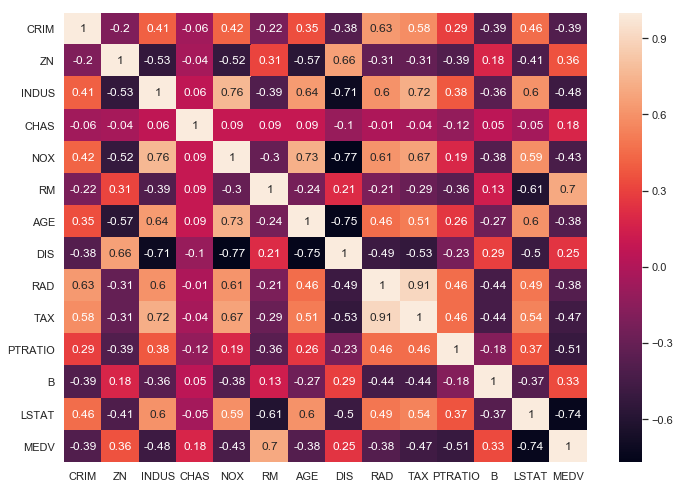

```python
sns.set(rc={'figure.figsize':(11.7,8.27)})
correlation_matrix = boston_df.corr().round(2)
sns.heatmap(data=correlation_matrix, annot=True)
```

# Another Dataset

## Handwritten digits - can we correctly classify them?

## Much more data this time (70,000 examples)

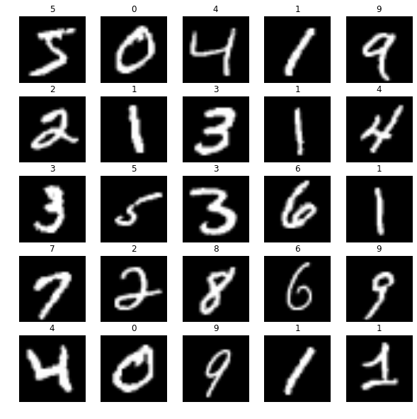

```python
plt.subplots_adjust(hspace=1)
plt.figure(figsize=(10, 10))
for n in range(25):
    img = X_train[n]
    plt.subplot(5,5,n + 1)
    plt.title(Y_train[n])
    plt.axis('off')
    plt.imshow(img, cmap='gray', interpolation='bilinear')
```

## How can we do this? Is our data different than the Boston Housing data?

## What does this data look like?

- Each image is a 28 x 28 matrix of pixel values from 0 to 255

```python
X_train[0]
```

```
array([[  0,   0,   0,   0,   0,   0,   0,   0,   0,   0,   0,   0,   0,
          0,   0,   0,   0,   0,   0,   0,   0,   0,   0,   0,   0,   0,
          0,   0],
       [  0,   0,   0,   0,   0,   0,   0,   0,   0,   0,   0,   0,   0,
          0,   0,   0,   0,   0,   0,   0,   0,   0,   0,   0,   0,   0,
          0,   0],
       [  0,   0,   0,   0,   0,   0,   0,   0,   0,   0,   0,   0,   0,
          0,   0,   0,   0,   0,   0,   0,   0,   0,   0,   0,   0,   0,
          0,   0],
       [  0,   0,   0,   0,   0,   0,   0,   0,   0,   0,   0,   0,   0,
          0,   0,   0,   0,   0,   0,   0,   0,   0,   0,   0,   0,   0,
          0,   0],
       [  0,   0,   0,   0,   0,   0,   0,   0,   0,   0,   0,   0,   0,
          0,   0,   0,   0,   0,   0,   0,   0,   0,   0,   0,   0,   0,
          0,   0],
       [  0,   0,   0,   0,   0,   0,   0,   0,   0,   0,   0,   0,   3,
         18,  18,  18, 126, 136, 175,  26, 166, 255, 247, 127,   0,   0,
          0,   0],
       [  0,   0,   0,   0,   0,   0,   0,   0,  30,  36,  94, 154, 170,
        253, 253, 253, 253, 253, 225, 172, 253, 242, 195,  64,   0,   0,
          0,   0],
       [  0,   0,   0,   0,   0,   0,   0,  49, 238, 253, 253, 253, 253,
        253, 253, 253, 253, 251,  93,  82,  82,  56,  39,   0,   0,   0,
          0,   0],
       [  0,   0,   0,   0,   0,   0,   0,  18, 219, 253, 253, 253, 253,
        253, 198, 182, 247, 241,   0,   0,   0,   0,   0,   0,   0,   0,
          0,   0],
       [  0,   0,   0,   0,   0,   0,   0,   0,  80, 156, 107, 253, 253,
        205,  11,   0,  43, 154,   0,   0,   0,   0,   0,   0,   0,   0,
          0,   0],
       [  0,   0,   0,   0,   0,   0,   0,   0,   0,  14,   1, 154, 253,
         90,   0,   0,   0,   0,   0,   0,   0,   0,   0,   0,   0,   0,
          0,   0],
       [  0,   0,   0,   0,   0,   0,   0,   0,   0,   0,   0, 139, 253,
        190,   2,   0,   0,   0,   0,   0,   0,   0,   0,   0,   0,   0,
          0,   0],
       [  0,   0,   0,   0,   0,   0,   0,   0,   0,   0,   0,  11, 190,
        253,  70,   0,   0,   0,   0,   0,   0,   0,   0,   0,   0,   0,
          0,   0],
       [  0,   0,   0,   0,   0,   0,   0,   0,   0,   0,   0,   0,  35,
```

[output cut: 29 more lines]

```
       [  0,   0,   0,   0,  55, 172, 226, 253, 253, 253, 253, 244, 133,
         11,   0,   0,   0,   0,   0,   0,   0,   0,   0,   0,   0,   0,
          0,   0],
       [  0,   0,   0,   0, 136, 253, 253, 253, 212, 135, 132,  16,   0,
          0,   0,   0,   0,   0,   0,   0,   0,   0,   0,   0,   0,   0,
          0,   0],
       [  0,   0,   0,   0,   0,   0,   0,   0,   0,   0,   0,   0,   0,
          0,   0,   0,   0,   0,   0,   0,   0,   0,   0,   0,   0,   0,
          0,   0],
       [  0,   0,   0,   0,   0,   0,   0,   0,   0,   0,   0,   0,   0,
          0,   0,   0,   0,   0,   0,   0,   0,   0,   0,   0,   0,   0,
          0,   0],
       [  0,   0,   0,   0,   0,   0,   0,   0,   0,   0,   0,   0,   0,
          0,   0,   0,   0,   0,   0,   0,   0,   0,   0,   0,   0,   0,
          0,   0]], dtype=uint8)
```

## We can take each 28 x 28 array and make it a 784 dim vector

## Now we have a problem much like the Boston Housing data problem -- we just have a 784 dimensional input.

```python
np.reshape(X_train[0], 784)
```

```
array([  0,   0,   0,   0,   0,   0,   0,   0,   0,   0,   0,   0,   0,
         0,   0,   0,   0,   0,   0,   0,   0,   0,   0,   0,   0,   0,
         0,   0,   0,   0,   0,   0,   0,   0,   0,   0,   0,   0,   0,
         0,   0,   0,   0,   0,   0,   0,   0,   0,   0,   0,   0,   0,
         0,   0,   0,   0,   0,   0,   0,   0,   0,   0,   0,   0,   0,
         0,   0,   0,   0,   0,   0,   0,   0,   0,   0,   0,   0,   0,
         0,   0,   0,   0,   0,   0,   0,   0,   0,   0,   0,   0,   0,
         0,   0,   0,   0,   0,   0,   0,   0,   0,   0,   0,   0,   0,
         0,   0,   0,   0,   0,   0,   0,   0,   0,   0,   0,   0,   0,
         0,   0,   0,   0,   0,   0,   0,   0,   0,   0,   0,   0,   0,
         0,   0,   0,   0,   0,   0,   0,   0,   0,   0,   0,   0,   0,
         0,   0,   0,   0,   0,   0,   0,   0,   0,   3,  18,  18,  18,
       126, 136, 175,  26, 166, 255, 247, 127,   0,   0,   0,   0,   0,
         0,   0,   0,   0,   0,   0,   0,  30,  36,  94, 154, 170, 253,
       253, 253, 253, 253, 225, 172, 253, 242, 195,  64,   0,   0,   0,
```

[output cut: 46 more lines]

## The output, however, is quite different. In the Boston Housing problem we were predicting a single value, how can we do that here?

## Let's consider a simpler problem: Suppose we have the same dataset, but we are only concerned if the number is a 7 or not a 7.

## We input a 784 dim vector

## We want to output if the image is a 7 or not a 7

## We input a 784 dim vector

## We want to output if the image is a 7 or not a 7 - let's output a 1 if it is a 7 and a 0 if it isn't.

## If this were like our linear regression example we would be looking for coefficients $w_1, w_2, \ldots, w_{784}$ and $c$ such that $$w_1x_1 + w_2x_2 + \cdots + w_{784}x_{784} + c$$ *best fits* our data.

## We'd like our inputs that are 7s to output 1, and everything else to output 0. The linear combination $$w_1x_1 + w_2x_2 + \cdots + w_{784}x_{784} + c$$ could take on any real values, so let's restrict it.

## Consider the sigmoid function

$$\sigma(z) = \frac{1}{1 + e^{-z}}$$

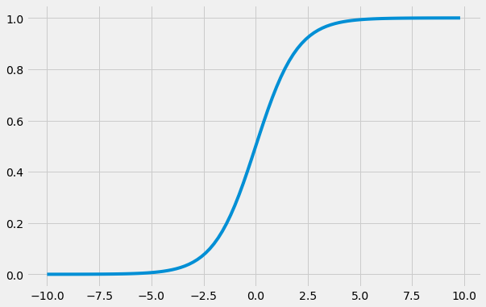

```python
plt.figure(figsize=(9, 6))
plt.style.use('fivethirtyeight')
x = np.arange(-10, 10, 0.2)
plt.axis('on')
plt.plot(x, 1 / (1 + np.exp(-x)))
```

## This bounds our output between 0 and 1.

## In our linear regression example, we looked at squared error and minimized to find the coefficients that gave us the *best fit*.

## Could we do that here? What would that look like?

## Let $\hat{y}$ represent our output value, the thing we want to be one when we have a 7 or 0 when we don't. Let $y$ be the actual value of our training example.

## Using squared error we could define our loss function as

$$\mathcal{L}(\hat{y}, y) = (y - \hat{y})^2 $$

## Using squared error we could define our loss function as

$$\mathcal{L}(\hat{y}, y) = (y - \hat{y})^2 $$

## This turns out to make the optimization problem non-convex.

## Instead, consider

$$ \mathcal{L}(\hat{y}, y) = - \left( y \log(\hat{y}) + (1 - y) \log(1 - \hat{y}) \right) $$

$$ \mathcal{L}(\hat{y}, y) = - \left( y \log(\hat{y}) + (1 - y) \log(1 - \hat{y}) \right) $$

## When $y = 1$

$$ \mathcal{L}(\hat{y}, 1) = - (1) \log(\hat{y}) = - \log(\hat{y}) $$

$$ \mathcal{L}(\hat{y}, y) = - \left( y \log(\hat{y}) + (1 - y) \log(1 - \hat{y}) \right) $$

## When $y = 1$

$$ \mathcal{L}(\hat{y}, 1) = - (1) \log(\hat{y}) = - \log(\hat{y}) $$

## Remember, we want to minimize our loss, so notice that $- \log(\hat{y})$ is minimized when $\hat{y}$ is large, but remember that $\hat{y}$ is bounded between 0 and 1, so the maximum value it can take on is 1. So our loss function wants our estimate to be as close to 1 as possible when our training example is a 7.

$$ \mathcal{L}(\hat{y}, y) = - \left( y \log(\hat{y}) + (1 - y) \log(1 - \hat{y}) \right) $$

## Similarly, when $y = 0$

$$ \mathcal{L}(\hat{y}, 0) = - \log(1 - \hat{y}) $$

## So our loss function wants our estimate, $\hat{y}$, to be 0 when our training example is not a 7.

# Review

## We want to predict if an image is a 7 or not a 7.

## We convert the image from a 28 x 28 array to a 784 vector

## This vector is our input and we want our output to be a 1 if we have a 7 and a 0 if we don't

## The output is computed as follows

$$ z(x) = w_1x_1 + w_2x_2 + \cdots + w_{784}x_{784} + c $$$$ \sigma(z) = \frac{1}{1 + e^{-z}} $$

## Overfitting

## We try to avoid this by splitting our data into a training set and a testing set.

[figure not shown]

-By Ghiles - Own work, CC BY-SA 4.0, https://commons.wikimedia.org/w/index.php?curid=47471056

## Conclusion

- Whatever shape the robot takeover comes in will require lots of data.
- That data needs to be fed through a model, so coercing the data into the right shape for the model might require compromise
- There is an incentive for people building these systems to simplify input to help make better models
  - i.e. turn things into glorified multiple choice
- There is some cool math in all of this
  - Consider the emotion reading problem for a humanoid robot.
- Oh yeah, one more thing...

## MMC Conference of Workshops - Next Saturday

- **112 ALGEBRA AND STANDARDS THROUGH STUDENTS IN MATH CLASSROOM Matthew Moran 6-12** In this workshop, we will look at some classic mathematical confusion with student work.
- **325 COLORING TO DEVELOPING STUDENTS IN ALGEBRA 2 Chu &** This session will be a great with the politics of the content and conceptual understanding.
- **308 THE STUDENT STRATEGIES FOR MATH MATH CLASSROOM Steve Viktora, John Benson 8-12** This session will be a group development of a standards and accessible for students to make a discussion of a fun and activities that promote a collaborative learning environment.
- **123 CCSSM: THE MATHEMATICS CLASSROOM Matthew Moran 6-14** We will discuss students want to use the structure of the mathematics to understand the standards as well as the role of the concepts and engaging activities that are activities to bring a log problem to allow students to make a collection.
- Note, these are fake and generated by an RNN trained on the talk descriptions from the 483 talks at past workshops from 2015 thru 2019